# Stat 480 - Homework #4

2/8/2018

# Check which of the variables are factors

```r
str(ChickWeight)
```

```
## Classes 'nfnGroupedData', 'nfGroupedData', 'groupedData' and 'data.frame':   578 obs. of  4 variables:
##  $ weight: num  42 51 59 64 76 93 106 125 149 171 ...
##  $ Time  : num  0 2 4 6 8 10 12 14 16 18 ...
##  $ Chick : Ord.factor w/ 50 levels "18"<"16"<"15"<..: 15 15 15 15 15 15 15 15 15 15 ...
##  $ Diet  : Factor w/ 4 levels "1","2","3","4": 1 1 1 1 1 1 1 1 1 1 ...
##  - attr(*, "formula")=Class 'formula'  language weight ~ Time | Chick
##   .. ..- attr(*, ".Environment")=<environment: R_EmptyEnv>
##  - attr(*, "outer")=Class 'formula'  language ~Diet
##   .. ..- attr(*, ".Environment")=<environment: R_EmptyEnv>
##  - attr(*, "labels")=List of 2
##   ..$ x: chr "Time"
##   ..$ y: chr "Body weight"
##  - attr(*, "units")=List of 2
##   ..$ x: chr "(days)"
##   ..$ y: chr "(gm)"
```

# Answer

Variables Chick and Diet are factors.

# Find a subset of the data for days 0, 10, and 21

```r
library(dplyr)
days <- filter(ChickWeight, Time %in% c(0, 10, 21))
```

# Draw side-by-side boxplots of weights by time

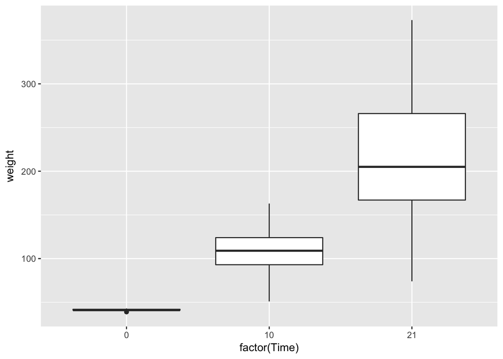

```r
library(ggplot2)
ggplot(data=days, aes(y=weight, x=factor(Time)))+geom_boxplot()
```

# Interpret the result

We can see boxs become larger through day 0 to day 21. All chick weights have the same value on day 0, so the box for day 0 is a horizontal line. Day 10 box is larger than day 0 box, which means that chick weights don’t have the same value at this time and they become varied. Similarly, chick weights becomes more varied on day 21 than day 10. We also can see boxes become higher through day 0 and day 21, which means chick weights become larger and larger as time went by. Overall, chick weights becomes larger and more varied through day 0 to day 21.

# Chicks’ weights compare on different diets

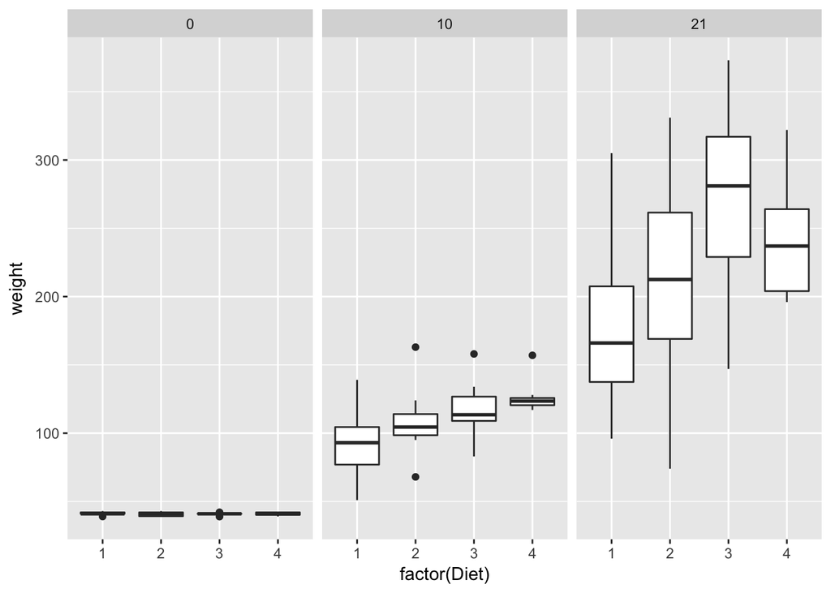

```r
ggplot(data=days, aes(x=factor(Diet), y=weight))+geom_boxplot()+facet_wrap(~Time)
```

# Answer

On day 0, chick weights all have the same value for 4 diets. On day 10, median chick weight increses from diet 1 to diet 4. Chick weights are most varied in diet 1 and least varied in diet 4. On day 21, median chick weight for diet 3 are the largest and diet 4 is the second largest one. Median chick weight in diet 1 is the smallest. Chick weights for diet 2 has the largest range.

# Find a subset of the data for days 21

```r
day21 <- filter(ChickWeight, Time %in% c(0,21))
```

# Chicks survive to day 21 on each of the diets

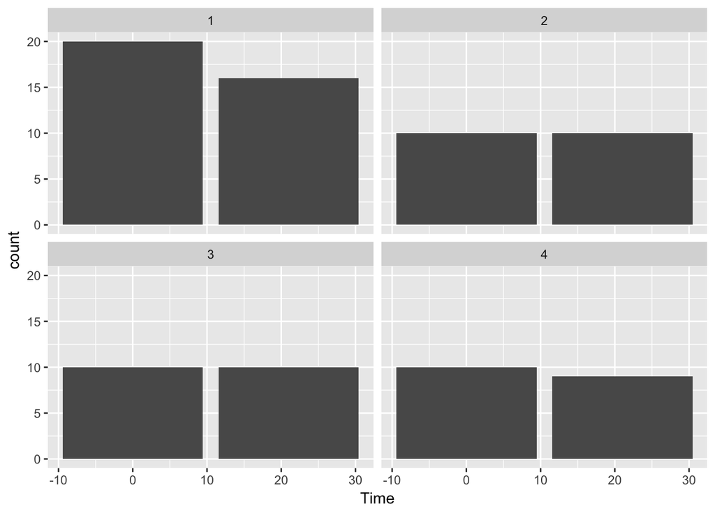

```r
ggplot(data=day21, aes(x=Time))+geom_bar()+facet_wrap(~Diet)
```

# Answer

For diet 2 and 3, it looks like that there is no chicks die in 21 days. We can see the bar on day 21 has the same height as the bar on day 0 for diet 2 and 3. For diet 4,very small amount of chicks died in 21 days, so heights of two bars are close. For diet 1, it has the largest number of chicks died in 21 days since the difference between two bars is obvious. However, the number is still less than 5.

# Introduce a separate dataset for each of the chicks 10, 25, 35, and 45

```r
day10 <- filter(ChickWeight, Chick == 10)
day25 <- filter(ChickWeight, Chick == 25)
day35 <- filter(ChickWeight, Chick == 35)
day45 <- filter(ChickWeight, Chick == 45)
```

# Determine the minimum weight for each dataset

```r
min(day10$weight)
```

```
## [1] 41
```

```r
min(day25$weight)
```

```
## [1] 40
```

```r
min(day35$weight)
```

```
## [1] 41
```

```r
min(day45$weight)
```

```
## [1] 41
```

# Introduce a variable `rel.gain` into each dataset

```r
day10$rel.gain <- (day10$weight - min(day10$weight)) / min(day10$weight)
day25$rel.gain <- (day25$weight - min(day25$weight)) / min(day25$weight)
day35$rel.gain <- (day35$weight - min(day35$weight)) / min(day35$weight)
day45$rel.gain <- (day45$weight - min(day45$weight)) / min(day45$weight)
```

# Combine the four data sets into one

```r
combine <- rbind(day10, day25, day35, day45)
```

# Plot lines to show weight gains over time for each of the chicks

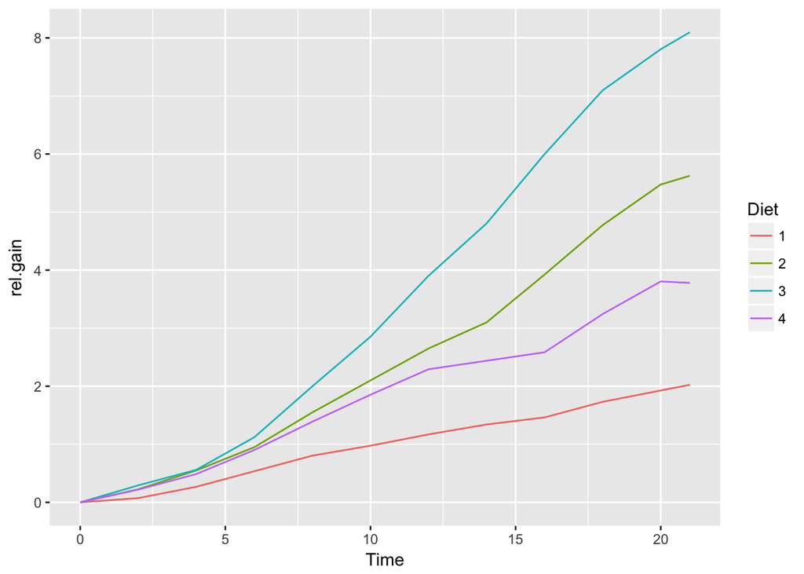

```r
ggplot(data=combine, aes(x=Time, y=rel.gain, colour=Diet))+geom_line()
```

# Interpret the result